# **Network analysis**

Bareket Karif

26 באפריל 2016

## **Grey’s anatomy**

#### *[Data source](http://www.babelgraph.org/data/ga_edgelist.csv)*

### **Question 1 - a**

### **edgelist data**

```
##  [1] "lexi"         "owen"         "sloan"        "torres"       "derek"        "karev"        "o'malley"     "yang"         "grey"         "chief"        "ellis grey"   "susan grey"   "bailey"
## [14] "izzie"        "altman"       "arizona"      "colin"        "preston"      "kepner"       "addison"      "nancy"        "olivia"       "mrs. seabury" "adele"        "thatch grey"  "tucker"
## [27] "hank"         "denny"        "finn"         "steve"        "ben"          "avery"
```

##### **Betweenness**

```
## [1] "sloan"
```

we got that **the betweenness is sloan**.

##### **Closeness**

```
## [1] "torres"
```

we got that **the closeness is torres**.

##### **Eigencetor**

```
## [1] "karev"
```

we got that **the eigencetor is karev**.

### **Question 1 - b**

##### **first algorithm**

**i. Print the networks by color code corresponding to the communities**

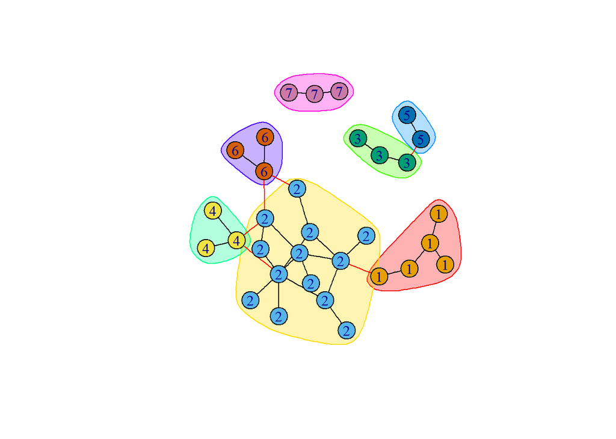

**ii. How communities received by each algorithm. What their size?**

```
## Community sizes
##  1  2  3  4  5  6  7
##  5 13  3  3  2  3  3
```

**iii. What is the value of modularity received?**

```
## [1] 0.5147059
```

##### **second algorithm**

**i. Print the networks by color code corresponding to the communities**

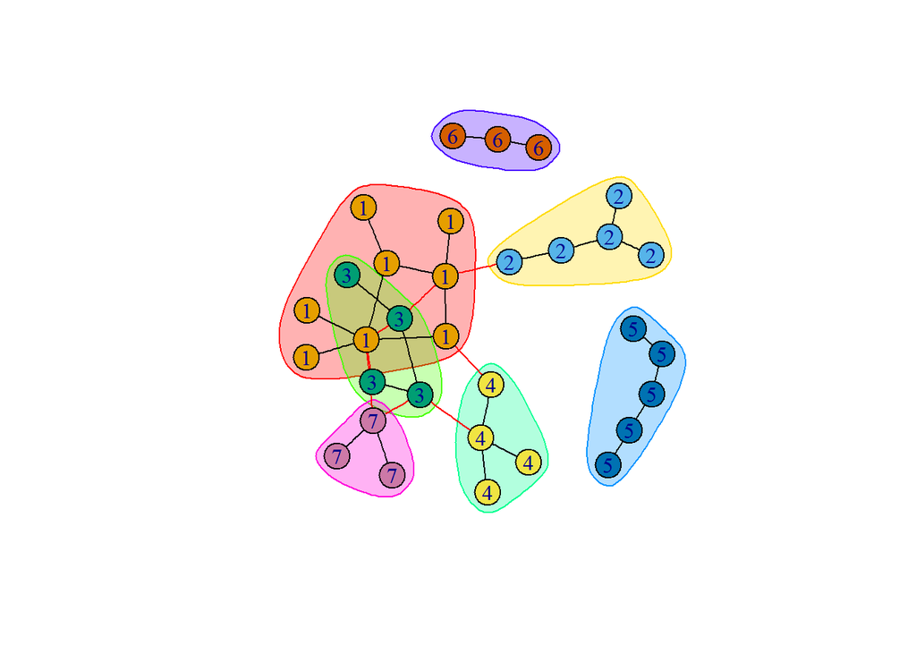

**ii. How communities received by each algorithm. What their size?**

```
## Community sizes
## 1 2 3 4 5 6 7
## 8 5 4 4 5 3 3
```

**iii. What is the value of modularity received?**

```
## [1] 0.5774221
```

## **Analyze dolphins data**

#### *[Data source](http://www-personal.umich.edu/~mejn/netdata/dolphins.zip)*

### **Question 2 - a**

### **Date Description:**

The file dolphins.gml contains an undirected social network of frequent associations between 62 dolphins in a community living off Doubtful Sound, New Zealand, as compiled by Lusseau et al. (2003). Please cite

D. Lusseau, K. Schneider, O. J. Boisseau, P. Haase, E. Slooten, and S. M. Dawson, The bottlenose dolphin community of Doubtful Sound features a large proportion of long-lasting associations, Behavioral Ecology and Sociobiology 54, 396-405 (2003).

Additional information on the network can be found in

D. Lusseau, The emergent properties of a dolphin social network, Proc. R. Soc. London B (suppl.) 270, S186-S188 (2003).

D. Lusseau, Evidence for social role in a dolphin social network, Preprint q-bio/0607048 (http://arxiv.org/abs/q-bio.PE/0607048)

### **edgelist data**

```
##  [1] "Beak"        "Beescratch"  "Bumper"      "CCL"         "Cross"       "DN16"        "DN21"        "DN63"        "Double"      "Feather"     "Fish"        "Five"        "Fork"        "Gallatin"
## [15] "Grin"        "Haecksel"    "Hook"        "Jet"         "Jonah"       "Knit"        "Kringel"     "MN105"       "MN23"        "MN60"        "MN83"        "Mus"         "Notch"       "Number1"
## [29] "Oscar"       "Patchback"   "PL"          "Quasi"       "Ripplefluke" "Scabs"       "Shmuddel"    "SMN5"        "SN100"       "SN4"         "SN63"        "SN89"        "SN9"         "SN90"
## [43] "SN96"        "Stripes"     "Thumper"     "Topless"     "TR120"       "TR77"        "TR82"        "TR88"        "TR99"        "Trigger"     "TSN103"      "TSN83"       "Upbang"      "Vau"
## [57] "Wave"        "Web"         "Whitetip"    "Zap"         "Zig"         "Zipfel"
```

##### **Betweenness**

```
## [1] "SN100"
```

we got that **the betweenness is SN100**.

##### **Closeness**

```
## [1] "SN100"
```

we got that **the closeness is SN100**.

##### **Eigencetor**

```
## [1] "Grin"
```

we got that **the eigencetor is Grin**.

### **Question 2 - b**

##### **first algorithm**

**i. Print the networks by color code corresponding to the communities**

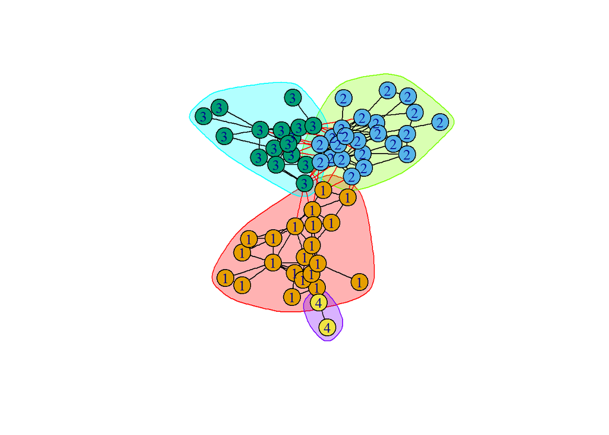

**ii. How communities received by each algorithm. What their size?**

```
## Community sizes
##  1  2  3  4
## 21 23 16  2
```

**iii. What is the value of modularity received?**

```
## [1] 0.4888454
```

##### **second algorithm**

**i. Print the networks by color code corresponding to the communities**

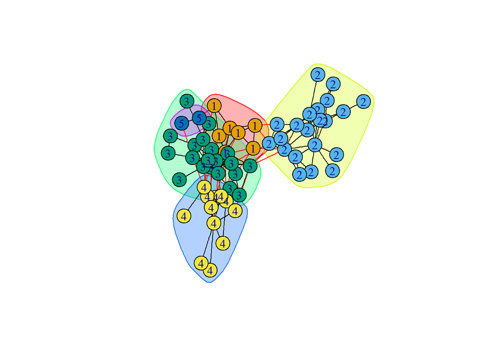

**ii. How communities received by each algorithm. What their size?**

```
## Community sizes
##  1  2  3  4  5
##  7 21 20 12  2
```

**iii. What is the value of modularity received?**

```
## [1] 0.5193821
```